# **Data Understanding**

# **Heatmap Korelasi**

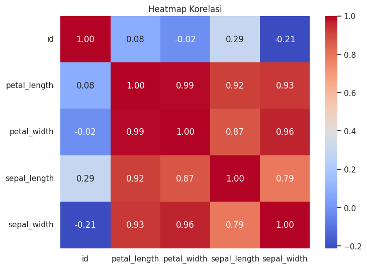

```python
import seaborn as sns
import matplotlib.pyplot as plt

# Heatmap Korelasi
plt.figure(figsize=(8,6))
sns.heatmap(numeric_columns.corr(), annot=True, cmap="coolwarm", fmt=".2f")
plt.title("Heatmap Korelasi")
plt.show()
```

# **Missing Values Visualization**

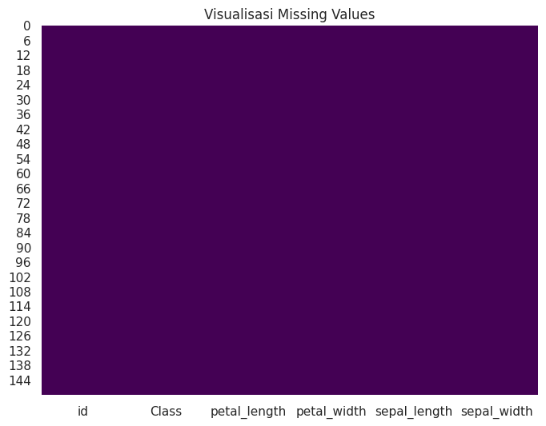

```python
# Visualisasi Data yang Hilang
plt.figure(figsize=(8,6))
sns.heatmap(df_combined.isnull(), cbar=False, cmap="viridis")
plt.title("Visualisasi Missing Values")
plt.show()
```

# **Histogram Distribusi Fitur**

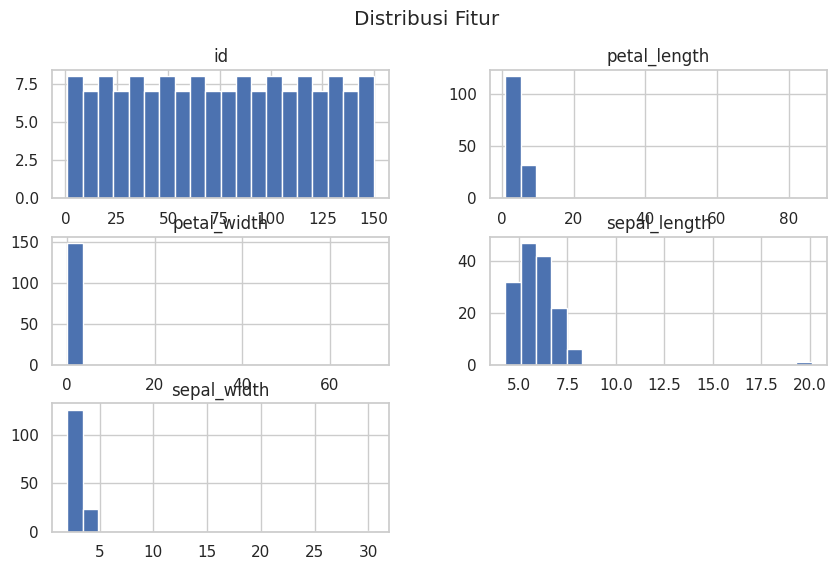

```python
# Histogram Distribusi untuk Setiap Kolom Numerik
numeric_columns.hist(figsize=(10, 6), bins=20)
plt.suptitle("Distribusi Fitur")
plt.show()
```

# **Scatter Plot Berdasarkan Kelas**

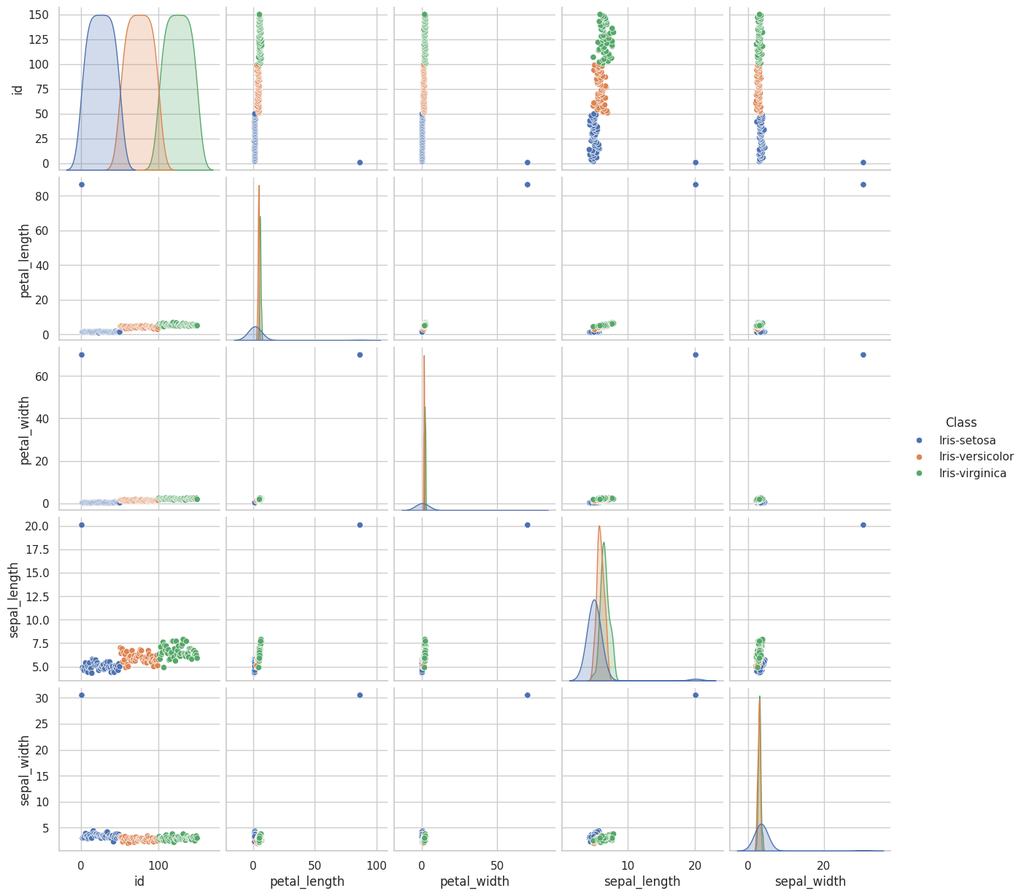

```python
# Scatter Plot menggunakan Pairplot dengan Warna berdasarkan Kelas
sns.pairplot(df_combined, hue="Class", diag_kind="kde")
plt.show()
```

```python
!jupyter nbconvert --to html data.ipynb
```

[output not shown]

```python
from google.colab import files
files.download("data.html")
```

[output not shown]

## **Algoritma K-Nearest Neighbor (KNN)**

Algoritma KNN atau K-Nearest Neighbor adalah salah satu algoritma yang banyak digunakan di dunia machine learning untuk kasus klasifikasi.

### **Apa itu Algoritma KNN?**

Seperti yang telah disebutkan, algoritma KNN merupakan algoritma klasifikasi yang bekerja dengan mengambil sejumlah K data terdekat (tetangganya) sebagai acuan untuk menentukan kelas dari data baru. Algoritma ini mengklasifikasikan data berdasarkan similarity atau kemiripan atau kedekatannya terhadap data lainnya.

Dalam K-Nearest Neighbor, data point yang berada berdekatan disebut “neighbor” atau “tetangga”.

Secara umum, cara kerja algoritma KNN adalah sebagai berikut.

1. Tentukan jumlah tetangga (K) yang akan digunakan untuk pertimbangan penentuan kelas.
2. Hitung jarak dari data baru ke masing-masing data point di dataset.
3. Ambil sejumlah K data dengan jarak terdekat, kemudian tentukan kelas dari data baru tersebut.

### **Menghitung jarak dengan Euclidean Distance**

Untuk menghitung jarak antara dua titik pada algoritma KNN digunakan metode Euclidean Distance yang dapat digunakan pada 1-dimensional space, 2-dimensional space, atau multi-dimensional space.

1-dimensional space berarti perhitungan jarak hanya menggunakan satu variabel bebas (independent variable), 2-dimensional-space berarti ada dua variabel bebas, dan multi-dimensional space berarti ada lebih dari dua variabel.

Secara umum, formula Euclidean distance pada 1-dimensional space adalah sebagai berikut.

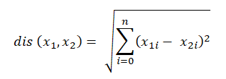

Formula di atas dapat digunakan jika jumlah independent variable hanya ada satu variabel. Lalu, bagaimana jika ada banyak variabel yang digunakan?

Jika ada lebih dari satu, kita dapat menjumlahkannya seperti di bawah ini.

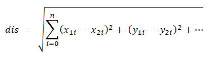

```python
# Pisahkan kolom numerik dan kategorikal
numerical_columns = df_combined.select_dtypes(include=[np.number]).columns
categorical_columns = df_combined.select_dtypes(include=[object]).columns

# Ganti nilai NaN pada kolom numerik dengan median dari setiap kolom
df_combined[numerical_columns] = df_combined[numerical_columns].fillna(df_combined[numerical_columns].median())

# Jika ingin menangani NaN pada kolom kategorikal (misalnya mengganti dengan mode)
df_combined[categorical_columns] = df_combined[categorical_columns].fillna(df_combined[categorical_columns].mode().iloc[0])

# Tampilkan hasil setelah penggantian NaN
print(df_combined.head())
```

```
   id        Class  petal_length  petal_width  sepal_length  sepal_width
0   1  Iris-setosa          86.4         70.0          20.1         30.5
1   2  Iris-setosa           1.4          0.2           4.9          3.0
2   3  Iris-setosa           1.3          0.2           4.7          3.2
3   4  Iris-setosa           1.5          0.2           4.6          3.1
4   5  Iris-setosa           1.4          0.2           5.0          3.6
```

### **Preprocessing Data**

Sebelum menggunakan KNN, kita perlu melakukan beberapa tahap preprocessing seperti menangani nilai NaN, memilih fitur numerik, dan membagi data menjadi fitur dan target.

```python
import numpy as np
from sklearn.model_selection import train_test_split
from sklearn.preprocessing import StandardScaler
from sklearn.neighbors import KNeighborsClassifier
from sklearn.metrics import accuracy_score

# Pisahkan kolom numerik dan kategorikal
numerical_columns = df_combined.select_dtypes(include=[np.number]).columns
categorical_columns = df_combined.select_dtypes(include=[object]).columns

# Mengganti NaN pada kolom numerik dengan median
df_combined[numerical_columns] = df_combined[numerical_columns].fillna(df_combined[numerical_columns].median())

# Jika ingin mengganti NaN pada kolom kategorikal (misalnya dengan mode)
df_combined[categorical_columns] = df_combined[categorical_columns].fillna(df_combined[categorical_columns].mode().iloc[0])

# Memilih fitur numerik (misalnya, semua kolom kecuali 'id' dan 'Class')
X = df_combined.drop(columns=["id", "Class"]).values
y = df_combined["Class"].values

# Membagi data menjadi set pelatihan dan pengujian
X_train, X_test, y_train, y_test = train_test_split(X, y, test_size=0.2, random_state=42)

# Melakukan standarasi fitur
scaler = StandardScaler()
X_train = scaler.fit_transform(X_train)
X_test = scaler.transform(X_test)

# Membuat dan melatih model KNN
knn = KNeighborsClassifier(n_neighbors=5)
knn.fit(X_train, y_train)

# Melakukan prediksi
y_pred = knn.predict(X_test)

# Menghitung akurasi
accuracy = accuracy_score(y_test, y_pred)
print(f"Akurasi model KNN: {accuracy:.4f}")
```

```
Akurasi model KNN: 0.9667
```

### **Menggunakan KNN untuk Klasifikasi**

KNN untuk melatih model dan membuat prediksi.

```python
# Membuat model KNN dengan k=3 (k tetangga terdekat)
knn = KNeighborsClassifier(n_neighbors=3)

# Latih model menggunakan data pelatihan
knn.fit(X_train, y_train)

# Prediksi kelas untuk data uji
y_pred = knn.predict(X_test)

# Evaluasi model menggunakan akurasi
accuracy = accuracy_score(y_test, y_pred)

# Menampilkan hasil akurasi
print(f"📌 Akurasi KNN: {accuracy * 100:.2f}%")
```

```
📌 Akurasi KNN: 93.33%
```

### **Menentukan Nilai K yang Optimal**

Untuk memilih nilai k yang optimal, Anda bisa mencoba beberapa nilai k dan memilih yang memberikan hasil terbaik. Misalnya:

```python
# Mencari nilai k terbaik (dari 1 hingga 20)
best_accuracy = 0
best_k = 1
for k in range(1, 21):
    knn = KNeighborsClassifier(n_neighbors=k)
    knn.fit(X_train, y_train)
    y_pred = knn.predict(X_test)
    accuracy = accuracy_score(y_test, y_pred)

    if accuracy > best_accuracy:
        best_accuracy = accuracy
        best_k = k

print(f"📌 Nilai k terbaik: {best_k}")
print(f"📌 Akurasi terbaik: {best_accuracy * 100:.2f}%")
```

```
📌 Nilai k terbaik: 1
📌 Akurasi terbaik: 100.00%
```

### **Visualisasi Hasil**

menampilkan visualisasi hasil klasifikasi dengan KNN

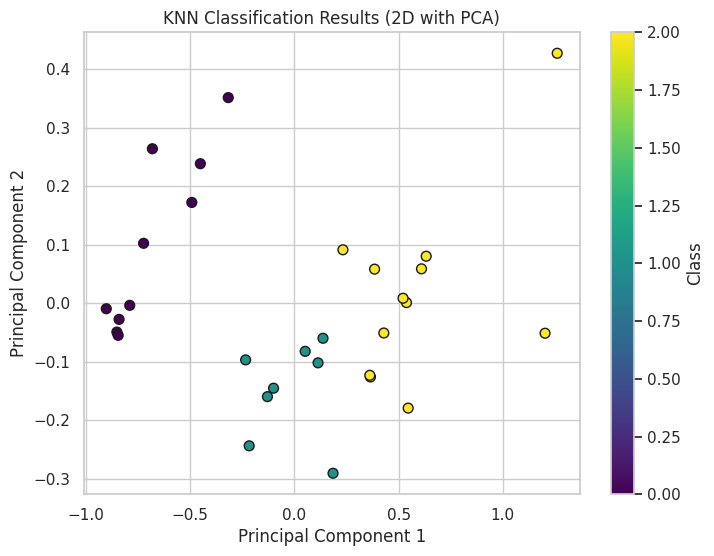

```python
from sklearn.decomposition import PCA
from sklearn.preprocessing import LabelEncoder
import matplotlib.pyplot as plt

# Jika data lebih dari 2 fitur, gunakan PCA untuk mereduksi menjadi 2 fitur
pca = PCA(n_components=2)
X_test_2d = pca.fit_transform(X_test)

# Mengonversi label kelas menjadi angka
label_encoder = LabelEncoder()
y_pred_numeric = label_encoder.fit_transform(y_pred)

# Visualisasi
plt.figure(figsize=(8, 6))
plt.scatter(X_test_2d[:, 0], X_test_2d[:, 1], c=y_pred_numeric, cmap='viridis', edgecolor='k', s=50)
plt.title("KNN Classification Results (2D with PCA)")
plt.xlabel("Principal Component 1")
plt.ylabel("Principal Component 2")
plt.colorbar(label='Class')
plt.show()
```

### **Penjelasan:**

Preprocessing:

Menangani NaN: Mengganti nilai NaN dengan nilai median untuk setiap kolom. Standardisasi: Menggunakan StandardScaler untuk menstandarkan fitur agar semua fitur memiliki skala yang sama. Pembagian Data: Data dibagi menjadi dua set: pelatihan (80%) dan pengujian (20%).

Model KNN: KNN dilatih dengan data pelatihan, dan digunakan untuk memprediksi kelas data pengujian.

Evaluasi: Model diuji menggunakan akurasi, yang mengukur seberapa baik model memprediksi kelas yang benar.

Pemilihan Nilai K Optimal: KNN sangat bergantung pada parameter k, yaitu jumlah tetangga terdekat yang digunakan untuk menentukan prediksi. Menemukan nilai k yang optimal dapat meningkatkan performa model.

```python
import pandas as pd
from sqlalchemy import create_engine
from tabulate import tabulate
import seaborn as sns

# 🎨 Aktifkan tema seaborn untuk tampilan tabel yang lebih menarik
sns.set_theme(style="whitegrid")

# Ambil data dari view_data_hitung
query_view = 'SELECT * FROM data_hitung'
df_view = pd.read_sql(query_view, pg_engine)

# Tampilkan data dalam format tabel yang lebih menarik menggunakan tabulate
print(tabulate(df_view, headers='keys', tablefmt='fancy_grid'))
```

```
╒═════╤══════╤═════════════════╤════════════════╤═══════════════╤════════════════╤═══════════════╤═════════════╤════════╕
│     │   id │ Class           │ petal_length   │ petal_width   │ sepal_length   │ sepal_width   │ euclide     │   rank │
╞═════╪══════╪═════════════════╪════════════════╪═══════════════╪════════════════╪═══════════════╪═════════════╪════════╡
│   0 │    1 │ Iris-setosa     │ 86,40          │ 70,00         │ 20,1           │ 30,50         │ 114,3867562 │     11 │
├─────┼──────┼─────────────────┼────────────────┼───────────────┼────────────────┼───────────────┼─────────────┼────────┤
│   1 │    2 │ Iris-setosa     │ 1,40           │ 0,20          │ 4,9            │ 3,00          │ 114,4399406 │     10 │
├─────┼──────┼─────────────────┼────────────────┼───────────────┼────────────────┼───────────────┼─────────────┼────────┤
│   2 │    3 │ Iris-setosa     │ 1,30           │ 0,20          │ 4,7            │ 3,20          │ 114,3287365 │     15 │
├─────┼──────┼─────────────────┼────────────────┼───────────────┼────────────────┼───────────────┼─────────────┼────────┤
│   3 │    4 │ Iris-setosa     │ 1,50           │ 0,20          │ 4,6            │ 3,10          │ 114,2307314 │     20 │
├─────┼──────┼─────────────────┼────────────────┼───────────────┼────────────────┼───────────────┼─────────────┼────────┤
│   4 │    5 │ Iris-setosa     │ 1,40           │ 0,20          │ 5              │ 3,60          │ 113,7624718 │     44 │
├─────┼──────┼─────────────────┼────────────────┼───────────────┼────────────────┼───────────────┼─────────────┼────────┤
│   5 │    6 │ Iris-setosa     │ 1,70           │ 0,40          │ 5,4            │ 3,90          │ 114,2705124 │     16 │
├─────┼──────┼─────────────────┼────────────────┼───────────────┼────────────────┼───────────────┼─────────────┼────────┤
│   6 │    7 │ Iris-setosa     │ 1,40           │ 0,30          │ 4,6            │ 3,40          │ 114,2036339 │     22 │
├─────┼──────┼─────────────────┼────────────────┼───────────────┼────────────────┼───────────────┼─────────────┼────────┤
│   7 │    8 │ Iris-setosa     │ 1,50           │ 0,20          │ 5              │ 3,40          │ 114,4783386 │      7 │
├─────┼──────┼─────────────────┼────────────────┼───────────────┼────────────────┼───────────────┼─────────────┼────────┤
│   8 │    9 │ Iris-setosa     │ 1,40           │ 0,20          │ 4,4            │ 2,90          │ 114,3495518 │     10 │
├─────┼──────┼─────────────────┼────────────────┼───────────────┼────────────────┼───────────────┼─────────────┼────────┤
│   9 │   10 │ Iris-setosa     │ 1,50           │ 0,10          │ 4,9            │ 3,10          │ 114,0805856 │     26 │
├─────┼──────┼─────────────────┼────────────────┼───────────────┼────────────────┼───────────────┼─────────────┼────────┤
│  10 │   11 │ Iris-setosa     │ 1,50           │ 0,20          │ 5,4            │ 3,70          │ 114,155946  │     23 │
├─────┼──────┼─────────────────┼────────────────┼───────────────┼────────────────┼───────────────┼─────────────┼────────┤
│  11 │   12 │ Iris-setosa     │ 1,60           │ 0,20          │ 4,8            │ 3,40          │ 114,4611288 │      8 │
├─────┼──────┼─────────────────┼────────────────┼───────────────┼────────────────┼───────────────┼─────────────┼────────┤
│  12 │   13 │ Iris-setosa     │ 1,40           │ 0,10          │ 4,8            │ 3,00          │ 114,7518627 │      2 │
├─────┼──────┼─────────────────┼────────────────┼───────────────┼────────────────┼───────────────┼─────────────┼────────┤
│  13 │   14 │ Iris-setosa     │ 1,10           │ 0,10          │ 4,3            │ 3,00          │ 114,1832737 │     19 │
├─────┼──────┼─────────────────┼────────────────┼───────────────┼────────────────┼───────────────┼─────────────┼────────┤
│  14 │   15 │ Iris-setosa     │ 1,20           │ 0,20          │ 5,8            │ 4,00          │ 113,7573734 │     35 │
├─────┼──────┼─────────────────┼────────────────┼───────────────┼────────────────┼───────────────┼─────────────┼────────┤
│  15 │   16 │ Iris-setosa     │ 1,50           │ 0,40          │ 5,7            │ 4,40          │ 114,0605979 │     23 │
├─────┼──────┼─────────────────┼────────────────┼───────────────┼────────────────┼───────────────┼─────────────┼────────┤
│  16 │   17 │ Iris-setosa     │ 1,30           │ 0,40          │ 5,4            │ 3,90          │ 114,1800771 │     19 │
├─────┼──────┼─────────────────┼────────────────┼───────────────┼────────────────┼───────────────┼─────────────┼────────┤
│  17 │   18 │ Iris-setosa     │ 1,40           │ 0,30          │ 5,1            │ 3,50          │ 113,8087431 │     32 │
├─────┼──────┼─────────────────┼────────────────┼───────────────┼────────────────┼───────────────┼─────────────┼────────┤
│  18 │   19 │ Iris-setosa     │ 1,70           │ 0,30          │ 5,7            │ 3,80          │ 114,0350385 │     22 │
```

[output cut: 248 more lines]

```
├─────┼──────┼─────────────────┼────────────────┼───────────────┼────────────────┼───────────────┼─────────────┼────────┤
│ 143 │  144 │ Iris-virginica  │ 5,90           │ 2,30          │ 6,8            │ 3,20          │ 109,4903649 │      7 │
├─────┼──────┼─────────────────┼────────────────┼───────────────┼────────────────┼───────────────┼─────────────┼────────┤
│ 144 │  145 │ Iris-virginica  │ 5,70           │ 2,50          │ 6,7            │ 3,30          │ 110,0569852 │      5 │
├─────┼──────┼─────────────────┼────────────────┼───────────────┼────────────────┼───────────────┼─────────────┼────────┤
│ 145 │  146 │ Iris-virginica  │ 5,20           │ 2,30          │ 6,7            │ 3,00          │ 110,6255395 │      2 │
├─────┼──────┼─────────────────┼────────────────┼───────────────┼────────────────┼───────────────┼─────────────┼────────┤
│ 146 │  147 │ Iris-virginica  │ 5,00           │ 1,90          │ 6,3            │ 2,50          │ 110,2662686 │      3 │
├─────┼──────┼─────────────────┼────────────────┼───────────────┼────────────────┼───────────────┼─────────────┼────────┤
│ 147 │  148 │ Iris-virginica  │ 5,20           │ 2,00          │ 6,5            │ 3,00          │ 109,872244  │      3 │
├─────┼──────┼─────────────────┼────────────────┼───────────────┼────────────────┼───────────────┼─────────────┼────────┤
│ 148 │  149 │ Iris-virginica  │ 5,40           │ 2,30          │ 6,2            │ 3,40          │ 110,5387715 │      2 │
├─────┼──────┼─────────────────┼────────────────┼───────────────┼────────────────┼───────────────┼─────────────┼────────┤
│ 149 │  150 │ Iris-virginica  │ 5,10           │ 1,80          │ 5,9            │ 3,00          │ 117,0436671 │      1 │
╘═════╧══════╧═════════════════╧════════════════╧═══════════════╧════════════════╧═══════════════╧═════════════╧════════╛
```

```python
# 📌 Import library yang diperlukan
import numpy as np
import matplotlib.pyplot as plt
import pandas as pd
from sklearn.neighbors import NearestNeighbors  # Model KNN untuk mendeteksi outlier
from IPython.display import display  # Impor display untuk digunakan di Google Colab

# Pilih hanya kolom numerik dari data yang telah digabungkan (df_combined)
numerical_columns = df_combined.select_dtypes(include=[np.number]).columns

# Periksa apakah ada kolom numerik dalam dataset
if len(numerical_columns) == 0:
    print("⚠ Tidak ada kolom numerik untuk dianalisis.")
else:
    # Ambil hanya nilai numerik dari dataset untuk analisis outlier
    X = df_combined[numerical_columns].values

    # Tangani nilai NaN dengan menggantinya menggunakan nilai median dari setiap kolom
    X = np.nan_to_num(X, nan=np.nanmedian(X))

    # Tentukan jumlah tetangga (k) berdasarkan aturan umum: k = akar jumlah data
    k = max(3, int(np.sqrt(len(X))))  # Minimal k=3 untuk memastikan stabilitas perhitungan

    # Latih model KNN dan cari k tetangga terdekat untuk setiap data
    nbrs = NearestNeighbors(n_neighbors=k+1).fit(X)
    distances, indices = nbrs.kneighbors(X)

    # Ambil rata-rata jarak dari k tetangga terdekat (mengabaikan titik data itu sendiri)
    avg_distances = distances[:, 1:].mean(axis=1)

    # Tentukan threshold untuk mendeteksi outlier menggunakan persentil 99.5
    threshold = np.percentile(avg_distances, 99.5)

    # Temukan indeks data yang memiliki rata-rata jarak lebih besar dari threshold
    outliers = np.where(avg_distances > threshold)[0]

    # Tampilkan hasil jumlah outlier yang ditemukan
    print(f"📌 Total outliers ditemukan: {len(outliers)}\n")

    # Jika ada outlier, tampilkan indeks dan data outlier
    if len(outliers) > 0:
        print("Indeks Outliers:", outliers)
        print("\n🔍 Data Outliers:")
        display(df_combined.iloc[outliers])  # Gunakan display() dari IPython untuk Colab

        # Menghitung dan menampilkan rank berdasarkan jarak rata-rata
        outlier_distances = avg_distances[outliers]
        sorted_indices = np.argsort(outlier_distances)[::-1]  # Urutkan jarak outlier dari yang terbesar
        print("\n🔍 Rank Outliers berdasarkan jarak rata-rata:")
        for rank, idx in enumerate(sorted_indices, start=1):
            print(f"Rank {rank}: Indeks {outliers[idx]}, Jarak Rata-rata: {outlier_distances[idx]}")

    # Visualisasi outlier hanya jika data memiliki 2 fitur numerik (agar bisa digambarkan dalam 2D)
    if X.shape[1] == 2:
        plt.figure(figsize=(8,6))
        plt.scatter(X[:, 0], X[:, 1], label="Normal Data", alpha=0.6)  # Data normal
        plt.scatter(X[outliers, 0], X[outliers, 1], color='red', label="Outlier", edgecolors='k', s=100)  # Data outlier
        plt.xlabel(numerical_columns[0])
        plt.ylabel(numerical_columns[1])
        plt.title("Outlier Detection using KNN")
        plt.legend()
        plt.show()
```

```
📌 Total outliers ditemukan: 1

Indeks Outliers: [0]

🔍 Data Outliers:
```

|  | id | Class | petal_length | petal_width | sepal_length | sepal_width |
| --- | --- | --- | --- | --- | --- | --- |
| 0 | 1 | Iris-setosa | 86.4 | 70.0 | 20.1 | 30.5 |

```
🔍 Rank Outliers berdasarkan jarak rata-rata:
Rank 1: Indeks 0, Jarak Rata-rata: 114.47008830406774
```